# Model Elvaluation

James Margrove

26 Januar 2017

Load the ARM package

```r
require(arm)
```

Load the data and the final model

```r
load("Model.RData")
data <- read.table("data.txt", header = T)
data <- data[data$f.time != 0,]# remove the initial time point
# rows with NA's are not included in the model. Remove the NAs from the data.frame
rdata <- data[!is.na(data$dia),] # removes rows with NAs in dia
rdata <- rdata[!is.na(rdata$mortality),] # removes rows with NAs in dia
```

### Modify the binplot() funciton.

We evaluated the model by using a modified version of binnedplot from the arm package. The modifications to this function were an addition loess smoother on the standard binnedplot. I also used the binned data to draw a density plot, and a qqnorm plot with a qqline to evaluate the distribution of the residuals. The plot was used for evaluating the residuals agaist the fitted values and each fixed effect explanatory variable log(dia), mrico-topography, light, and soil texture))

Code to modify the binnedplot function from the arm package:

```r
newbinplot <-   function (x, y, nclass = NULL, xlab = "Expected Values", ylab = "Average residual",
            main = "", cex.pts = 0.8, col.pts = 1,
            col.int = "gray", ...)  {
    n <- length(x)
    if (is.null(nclass)) {
      if (n >= 100) {
        nclass = floor(sqrt(length(x)))
      }
      if (n > 10 & n < 100) {
        nclass = 10
      }
      if (n <= 10) {
        nclass = floor(n/2)
      }
    }
    aa <<- data.frame(binned.resids(x, y, nclass)$binned) # result, global
    plot(range(aa$xbar), range(aa$ybar, aa$X2se, -aa$X2se, na.rm = TRUE),
         xlab = xlab, ylab = ylab, type = "n", main = "", ...)
    abline(0, 0, lty = 2)
    lines(aa$xbar, aa$X2se, col = col.int)
    lines(aa$xbar, -aa$X2se, col = col.int)
    points(aa$xbar, aa$ybar, pch = 19, cex = cex.pts, col = col.pts)
    lines(loess.smooth(x = aa$xbar, y = aa$ybar), col = "red") # additional line of code here for the loess smoother
    plot(density(as.numeric(aa$ybar)), main = main) # density
    #qqnorm(aa$ybar, main = ""); qqline(aa$ybar) # qqnorm
    car::qqPlot(aa$ybar, col = "black", pch = 19, cex = .75, grid = FALSE, ylab = "Sample Quantiles", xlab = "Theoretical Quantiles")
}
```

Extract the residuals into a new data.frame called rdata

```r
rdata$resid <- resid(s3, type = "pearson") # add the residuals
rdata$fit <- fitted(s3)
```

The residuals of the overall model.

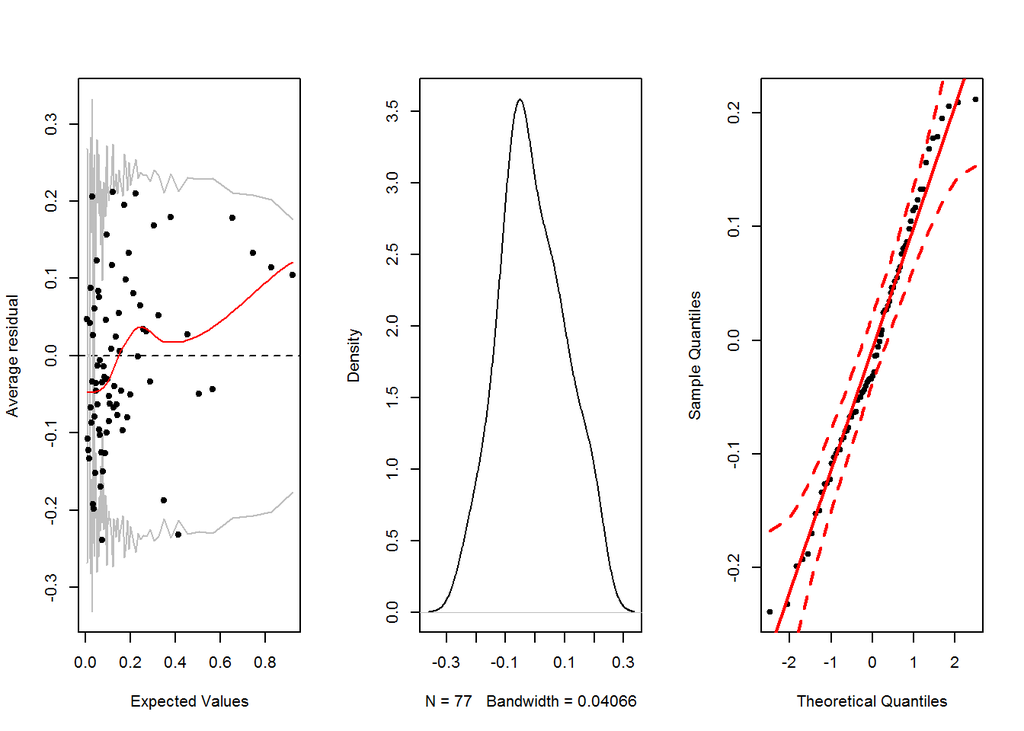

```r
par(mfrow=c(1,3))
newbinplot(rdata$fit, rdata$resid)
```

Assessing each of the continuous fixed effects (micro-topography and diameter)

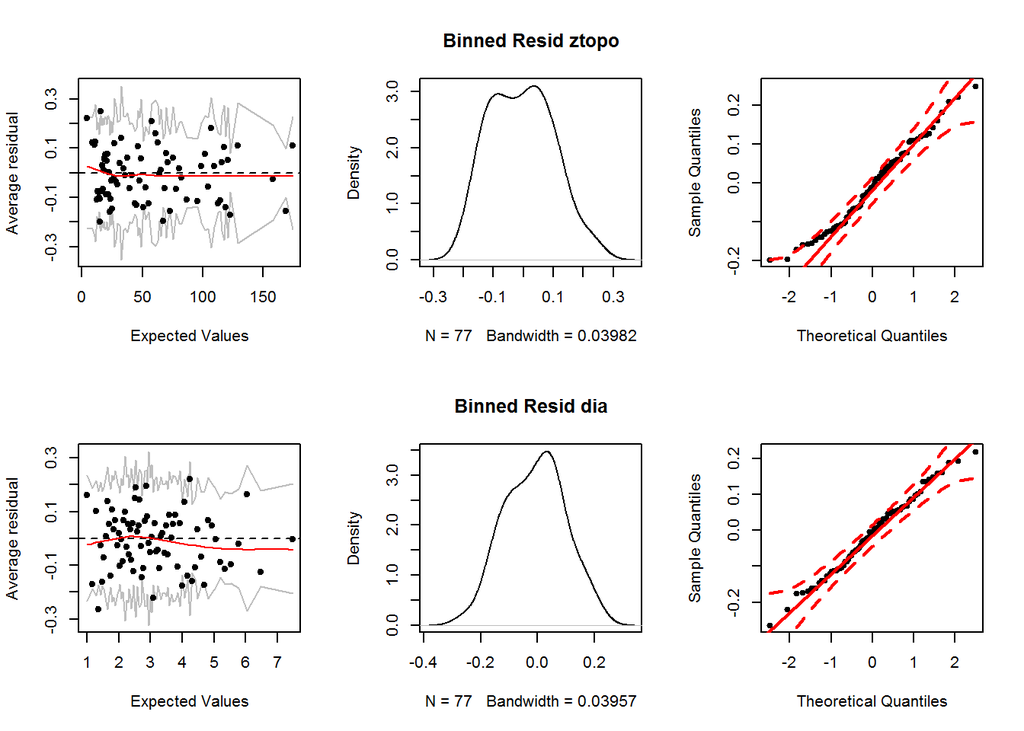

```r
par(mfrow=c(2,3))
fixNames <- c("ztopo","dia")
sapply(fixNames, FUN = function(x) newbinplot(rdata[,x], rdata[,"resid"],
                                              main = paste("Binned Resid", x)))
```

Boxplot of the residuals by census interval (f.time)

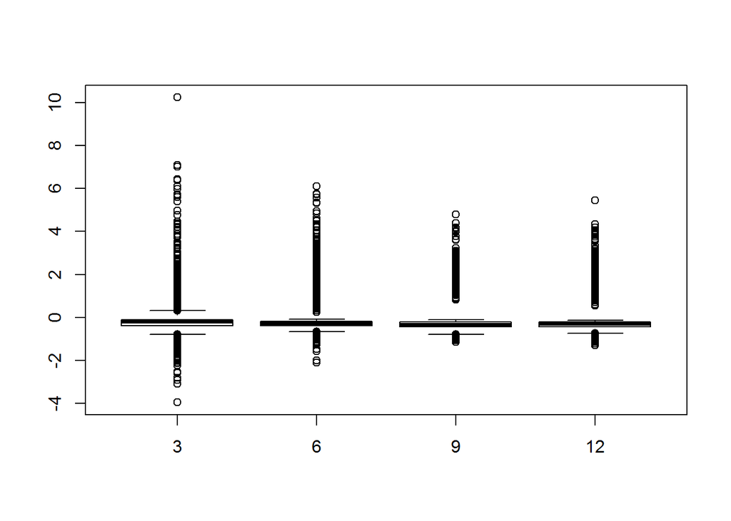

```r
par(mfrow=c(1,1))
with(rdata, boxplot(resid ~ f.time))
```

Boxplot of the residuals by the factor flood (seeding water innundated or not)

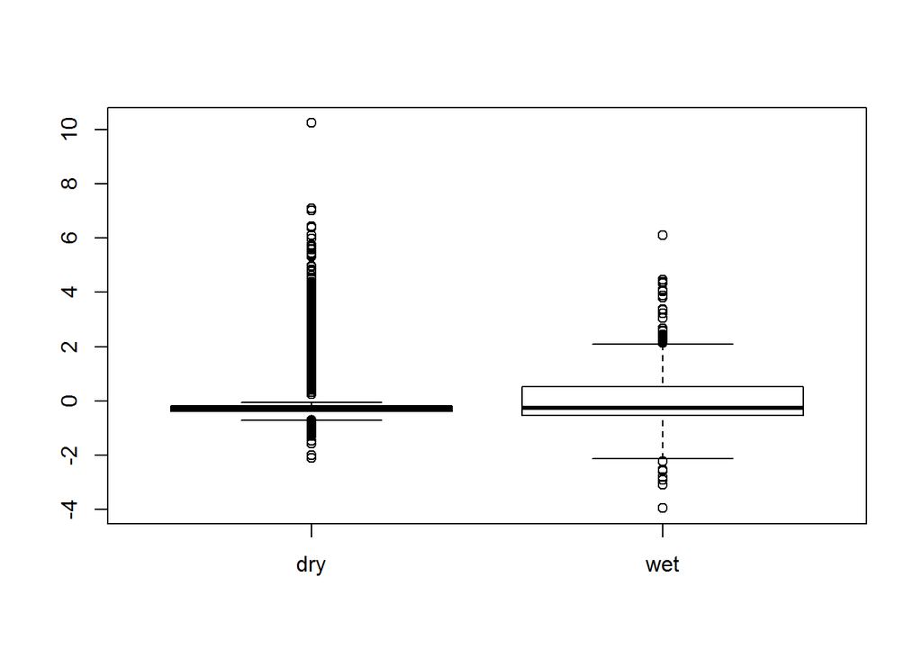

```r
with(rdata, boxplot(resid ~ flood))
```

Boxplot of the residuals by the factor species (sp)

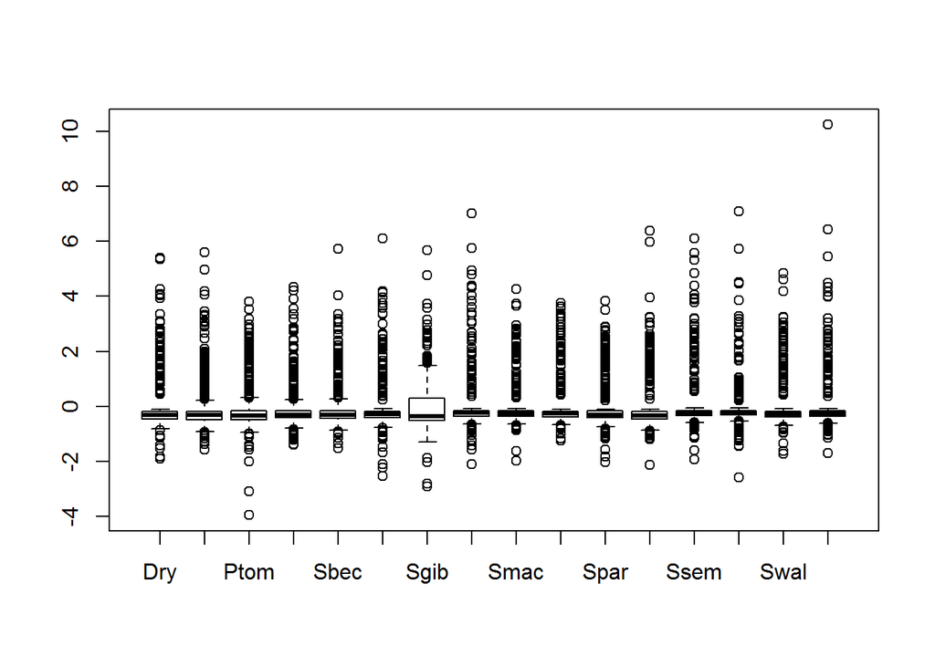

```r
with(rdata, boxplot(resid ~ sp))
```

## Random effects

A funciton to asses the random effects. - intercept is the factor of teh random effect - slope is weather the random effect varies with anything - model is the model

Plots a qqplot with the line Plots a density plot of the random effects Gives the Shapiro test p-value: testing the null hypothesis that the data do not differ from normality

```r
ranNorm <- function(intercept = NULL, slope = 1, model = NULL){
if(slope >= 2){par(mfcol=c((2),(1*slope)))}else{par(mfrow=c(1,2))} # orentation of the graphs
for(i in 1:slope){  # loop depends on how many slopes there are.
MAIN <- paste("RanEffect:", intercept) # title
ranEffects <- ranef(model)
effect <- ranEffects[[intercept]][[i]] # exctaract the random effects
qqnorm(effect, main = MAIN); qqline(effect) # qqnorm graph, with line
pvalue <- round(shapiro.test(effect)[[2]], digit = 3) # pvalue
plot(density(effect), main = paste("shp_test:",pvalue))}} # density plot with p-value
```

### BlockL:wl (plot)

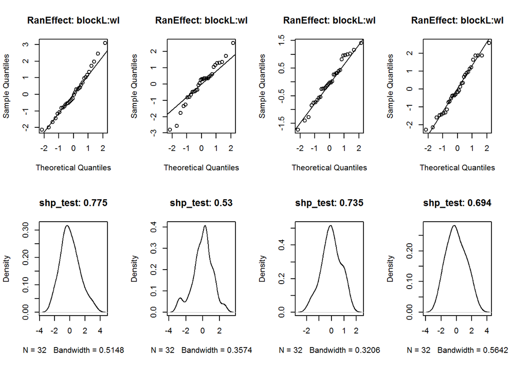

```r
ranNorm("blockL:wl", slope = 4, model = s3)
```

The four census period for each plot (n=32) seem to be normally distributed.